In an effort to save resources, we have set up the Jupyter spaces so that they expire after 6 months, or when they have not been used for 3 months (whichever comes first).

If you want to be able to work on your Jupyter exercises after your first Jupyter space expires, you will need to save the notebooks with your existing work BEFORE YOUR FIRST ACCOUNT EXPIRES, and then upload them to a new Jupyter space.

Please use the following steps to save and upload your notebooks to a new space:

Download your notebooks from your initial Jupyter account (BEFORE YOUR ORIGINAL ACCOUNT EXPIRES)

Step 1: Open a Jupyter notebook in the Jupyter environment.

Step 2: In the upper left-hand corner, choose File > Download As > IPython Notebook (.ipynb). Save the notebook in a location you will be able to find later.

Step 3: Repeat this for all the notebooks you want to move to your new Jupyter account.

Upload your saved notebooks into a new Jupyter space:

Step 1: AFTER YOUR INITIAL JUPYTER ACCOUNT EXPIRES, access Jupyter from any notebook link in the course website (just as you did when you started the course). Doing so will automatically set up a new space for you.

Step 2: In your new space, click on the Jupyter icon (top left) from one of your notebooks to access the Jupyter home page. You will see a list of all the course notebooks, that looks something like this:

[figure not shown]

Step 3: To upload the saved notebook(s) from your computer to the Jupyter server, click the “Upload” button on the upper right. Navigate to the folder on your computer where you saved an old notebook, select that file (or files) and click Open. Repeat for all the notebooks you want to upload.

Step 4: If the notebooks you are uploading have the same file name as the original notebooks, your uploads will overwrite the new "clean" copies of the notebooks. If this is ok with you, click the blue "Upload" button beside the notebook(s) you want to upload.

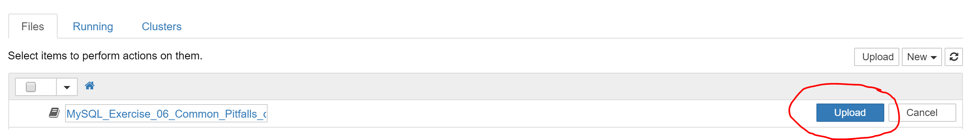

If you prefer to preserve the new clean copies of the notebooks and upload your working notebooks separately, then adjust the file names (titles) of the notebook(s) you are uploading, before clicking the blue "Upload" button.

Your notebooks are now ready to use!

**Two things to remember:**

1. If you altered the file names of the notebooks when you uploaded them, the links from the course site will no longer work (the links will take you to the clean versions of the notebooks, rather than your working versions). Instead, access your working notebooks from the Jupyter home page.
2. Because this is a new Jupyter account with a new server and port number, if you previously had problems with firewalls and needed to open a port for Jupyter, you will need to adjust that to allow the new port number.